# Analisi dei Dati sui Suicidi nel Mondo con focus sul Giappone

*Un'analisi dettagliata del trend sui suicidi nel mondo con un focus sul Giappone*

# 1. Introduzione

In questo progetto, andrò ad analizzare il trend dei suicidi nel mondo, esplorando fattori come genere, e fascia d'età. Utilizzerò un dataset preso da kaggle.com per identificare modelli e tendenze significative.

Il suicidio è un importante problema di sanità pubblica e la riduzione del tasso di mortalità per suicidio è uno degli obiettivi target dell’agenda delle Nazioni Unite 2030 per lo sviluppo sostenibile (https://sdgs.un.org/). Nel 2016 si sono verificati nel mondo circa 800.000 suicidi, corrispondenti a un tasso grezzo di mortalità di 10,6 per 100.000 abitanti (13,5 tra gli uomini e 7,7 tra le donne). A livello globale, nel 2016, il tasso di mortalità per suicidio è stato di 1,75 volte più elevato tra gli uomini rispetto alle donne. Si stima, invece, che i tentativi di suicidio, per i quali non esiste un flusso di dati consolidato come per i decessi, siano più frequenti tra le donne, le quali più spesso si avvalgono di metodi meno letali (ad esempio, l’avvelenamento) che consentono interventi di soccorso. I tassi di mortalità per suicidio in assoluto più bassi, per entrambi i generi, si registrano nei Paesi del bacino del Mediterraneo. L’Italia con un tasso grezzo di 8,2 per 100.000 abitanti (su tutte le età) resta uno dei Paesi con la mortalità per suicidio più bassa d’Europa (https://www.who.int/publications/i/item/world-health-statistics-2019-monitoring-health-for-the-sdgs-sustainable-development-goals).

Dal 2000 al 2016 il tasso grezzo di mortalità per suicidio a livello globale è diminuito del 16% tra gli uomini e del 20% tra le donne (https://www.who.int/publications/i/item/world-health-statistics-2019-monitoring-health-for-the-sdgs-sustainable-development-goals). In Italia, si è osservato in passato che la diminuzione dei tassi, per entrambi i generi, ha inizio per le età adulte e anziane (55 anni e più) a metà degli anni ’80; mentre per i più giovani i tassi di suicidio cominciano a ridursi in maniera significativa a partire dalla seconda metà degli anni ’90, ad eccezione delle donne di 25-44 anni per le quali si è osservato un decremento continuo del tasso dal 1980 al 2002 (https://doi.org/10.1016/j.psychres.2008.12.008). In corrispondenza della crisi economico-finanziaria del 2008 è stato documentato un aumento dei suicidi in molti Paesi; in Italia, tale aumento ha riguardato quasi esclusivamente gli uomini in età lavorativa e si è protratto negli anni seguenti la crisi almeno fino al 2016 (ultimo anno per il quale il dato è riportato) (https://doi.org/10.1111/hsc.12086). La crisi economica del 2008 non ha invece determinato un aumento dei suicidi tra gli anziani, per i quali si è osservato un declino costante dei tassi (https://doi.org/10.1111/hsc.12086, https://doi.org/10.1007/s40520-019-01431-z).

I tassi di mortalità per suicidio sono più elevati tra gli anziani, ma è tra i giovani che il suicidio rappresenta la percentuale più importante sul totale dei decessi; in Italia, così come nel resto del mondo, il suicidio è la terza più frequente causa di morte tra le persone di 15-29 anni. Inoltre, sebbene anche tra i giovani i suicidi siano nel complesso diminuiti rispetto al passato, questa riduzione è stata molto meno consistente rispetto a quanto osservato per altre cause di morte, come ad esempio gli incidenti stradali (https://doi.org/10.1007/s00787-009-0007-x, https://doi.org/10.1007/s00787-011-0238-5).

# 1.1 I fattori di rischio per il suicidio

I fattori di rischio per il suicidio possono essere suddivisi in fattori individuali, sociali, ambientali e culturali. Secondo l'Organizzazione Mondiale della Sanità (OMS), i principali fattori di rischio individuali includono tentativi di suicidio precedenti, malattie mentali, alcolismo, difficoltà finanziarie o disoccupazione, disperazione, dolori cronici, suicidi in famiglia, fattori genetici e biologici, e conflitti relazionali (https://www.bag.admin.ch/bag/it/home/strategie-und-politik/politische-auftraege-und-aktionsplaene/aktionsplan-suizidpraevention/suizide-und-suizidversuche/risiko-und-schutzfaktoren-zu-suiziden.html).

Inoltre, la ricerca ha dimostrato l'importanza dell'interazione tra fattori biologici, psicologici, sociali, ambientali e culturali sulla vulnerabilità di una persona al comportamento suicidario (https://www.giuntipsy.it/informazioni/notizie/suicidio-fattori-di-rischio-e-prevenzione).

I fattori di rischio sociali e ambientali includono la cessazione di un rapporto di coppia, sentimenti di solitudine, assenza di sostegno sociale, esperienze traumatiche o maltrattamenti, discriminazione, esperienze migratorie stressanti, catastrofi naturali e guerre, stigmatizzazione di una richiesta di aiuto, insensibilità della copertura mediatica, accesso a mezzi e metodi letali, e difficoltà d'accesso all'assistenza sanitaria (https://www.bag.admin.ch/bag/it/home/strategie-und-politik/politische-auftraege-und-aktionsplaene/aktionsplan-suizidpraevention/suizide-und-suizidversuche/risiko-und-schutzfaktoren-zu-suiziden.html).

È importante sottolineare che il suicidio è la conseguenza di una complessa costellazione di questi fattori di rischio e di protezione (https://www.bag.admin.ch/bag/it/home/strategie-und-politik/politische-auftraege-und-aktionsplaene/aktionsplan-suizidpraevention/suizide-und-suizidversuche/risiko-und-schutzfaktoren-zu-suiziden.html).

# 1.2 Dati Utilizzati

- I dati sono stati presi da '[Suicide Rates Overview 1985 to 2016](https://www.kaggle.com/datasets/russellyates88/suicide-rates-overview-1985-to-2016)' sul sito *[Kaggle](https://www.kaggle.com)*, esso contiene il numero dei suicidi annuali di 101 paesi, divisi per sesso e fasce d'età, inoltre contiene il tasso di suicidi annuale di ogni paese (suicidi per 100mila persone) dal 1985 al 2016.

# 1.3 Obiettivi

- Obiettivo di questo lavoro è fornire un quadro del fenomeno suicidario nel mondo, analizzando il trend temporale e la variabilità dei tassi di suicidio per Stato, fasce d'età e genere.

# 2. Analisi, preparazione ed elaborazione dati

## 2.1 Importazione Librerie

```python
import pandas as pd
import matplotlib.pyplot as plt
import seaborn as sns
```

```python
# Caricare il dataset da un file CSV
df = pd.read_csv('master.csv')
print(df)
```

```
          country  year     sex          age  suicides_no  population  \
0         Albania  1987    male  15-24 years           21      312900
1         Albania  1987    male  35-54 years           16      308000
2         Albania  1987  female  15-24 years           14      289700
3         Albania  1987    male    75+ years            1       21800
4         Albania  1987    male  25-34 years            9      274300
...           ...   ...     ...          ...          ...         ...
27815  Uzbekistan  2014  female  35-54 years          107     3620833
27816  Uzbekistan  2014  female    75+ years            9      348465
27817  Uzbekistan  2014    male   5-14 years           60     2762158
27818  Uzbekistan  2014  female   5-14 years           44     2631600
27819  Uzbekistan  2014  female  55-74 years           21     1438935

       suicides/100k pop    country-year  HDI for year  gdp_for_year ($)   \
0                   6.71     Albania1987           NaN      2,156,624,900
```

[output cut: 25 more lines]

## 2.2 Gestione valori mancanti

```python
# Caricare il dataset da un file CSV
df = pd.read_csv('master.csv')
print(df)

# Verifica i valori mancanti in ciascuna colonna
missing_values = df.isnull().sum()
print("Valori mancanti per colonna:")
print(missing_values)
```

```
          country  year     sex          age  suicides_no  population  \
0         Albania  1987    male  15-24 years           21      312900
1         Albania  1987    male  35-54 years           16      308000
2         Albania  1987  female  15-24 years           14      289700
3         Albania  1987    male    75+ years            1       21800
4         Albania  1987    male  25-34 years            9      274300
...           ...   ...     ...          ...          ...         ...
27815  Uzbekistan  2014  female  35-54 years          107     3620833
27816  Uzbekistan  2014  female    75+ years            9      348465
27817  Uzbekistan  2014    male   5-14 years           60     2762158
27818  Uzbekistan  2014  female   5-14 years           44     2631600
27819  Uzbekistan  2014  female  55-74 years           21     1438935

       suicides/100k pop    country-year  HDI for year  gdp_for_year ($)   \
0                   6.71     Albania1987           NaN      2,156,624,900
1                   5.19     Albania1987           NaN      2,156,624,900
2                   4.83     Albania1987           NaN      2,156,624,900
3                   4.59     Albania1987           NaN      2,156,624,900
4                   3.28     Albania1987           NaN      2,156,624,900
...                  ...             ...           ...                ...
27815               2.96  Uzbekistan2014         0.675     63,067,077,179
27816               2.58  Uzbekistan2014         0.675     63,067,077,179
27817               2.17  Uzbekistan2014         0.675     63,067,077,179
27818               1.67  Uzbekistan2014         0.675     63,067,077,179
27819               1.46  Uzbekistan2014         0.675     63,067,077,179

       gdp_per_capita ($)       generation
0                     796     Generation X
1                     796           Silent
2                     796     Generation X
3                     796  G.I. Generation
4                     796          Boomers
...                   ...              ...
27815                2309     Generation X
27816                2309           Silent
27817                2309     Generation Z
27818                2309     Generation Z
27819                2309          Boomers

[27820 rows x 12 columns]
Valori mancanti per colonna:
country                   0
year                      0
sex                       0
age                       0
suicides_no               0
population                0
suicides/100k pop         0
country-year              0
HDI for year          19456
 gdp_for_year ($)         0
gdp_per_capita ($)        0
generation                0
dtype: int64
```

## 2.3 Eliminazione colonne superflue

```python
# Eliminazione delle colonne superflue
columns_to_drop = ['country-year', 'HDI for year', ' gdp_for_year ($) ' , 'gdp_per_capita ($)', 'generation']
df.drop(columns=columns_to_drop, inplace=True)

# Verifica che le colonne siano state eliminate correttamente
print("Colonne dopo l'eliminazione:")
print(df.columns)
```

```
Colonne dopo l'eliminazione:
Index(['country', 'year', 'sex', 'age', 'suicides_no', 'population',
       'suicides/100k pop'],
      dtype='object')
```

```python
# Mostra le prime righe del dataframe dopo l'eliminazione delle colonne
print(df.head())
```

```
   country  year     sex          age  suicides_no  population  \
0  Albania  1987    male  15-24 years           21      312900
1  Albania  1987    male  35-54 years           16      308000
2  Albania  1987  female  15-24 years           14      289700
3  Albania  1987    male    75+ years            1       21800
4  Albania  1987    male  25-34 years            9      274300

   suicides/100k pop
0               6.71
1               5.19
2               4.83
3               4.59
4               3.28
```

## 2.4 Paesi presenti nel dataset

```python
# Calcolo del numero di paesi nel dataset
num_countries = df['country'].nunique()
num_countries
```

```
101
```

## 2.5 Tipi di dati del file

```python
# Visualizza i tipi di dati delle colonne
print(df.dtypes)
```

```
country               object
year                   int64
sex                   object
age                   object
suicides_no            int64
population             int64
suicides/100k pop    float64
dtype: object
```

# 3. Analisi globale dei suicidi dal 1985 al 2016

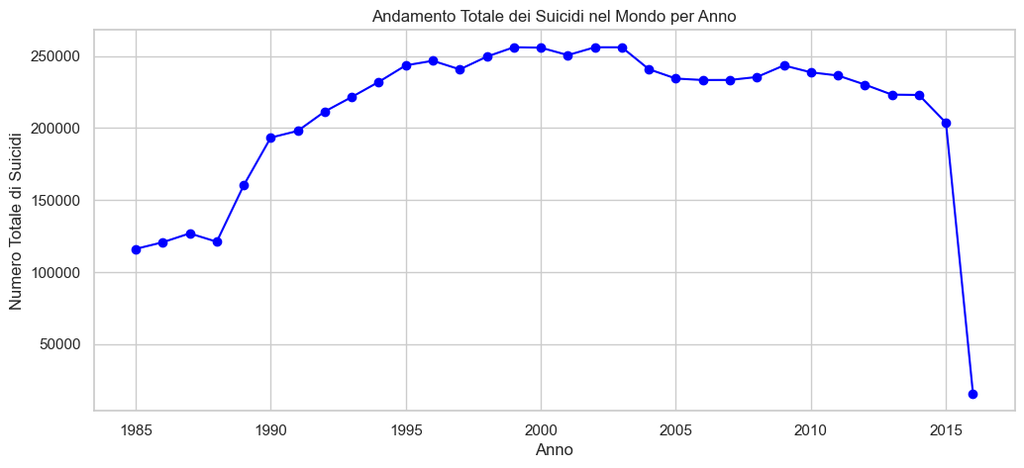

```python
# Impostazione dello stile dei grafici
sns.set(style="whitegrid")

# Calcolo del totale dei suicidi per anno
suicides_per_year = df.groupby('year')['suicides_no'].sum()

# Creazione del grafico
plt.figure(figsize=(12, 5))
suicides_per_year.plot(kind='line', color='blue', marker='o')
plt.title('Andamento Totale dei Suicidi nel Mondo per Anno')
plt.xlabel('Anno')
plt.ylabel('Numero Totale di Suicidi')
plt.grid(True)
plt.show()
```

## 3.1 Analisi globale dei suicidi per paese

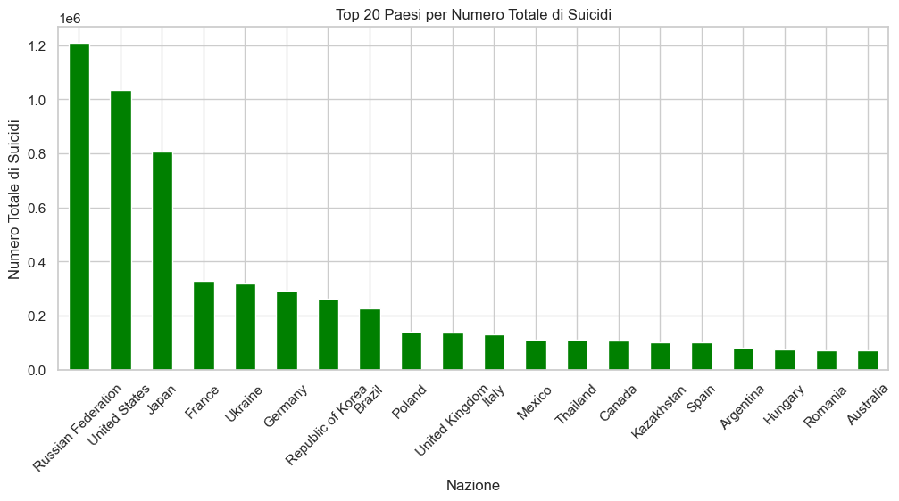

```python
# Calcolo del totale dei suicidi per paese
suicides_per_country = df.groupby('country')['suicides_no'].sum().sort_values(ascending=False)

# Prendiamo i primi 20 paesi per numero di suicidi
top_countries = suicides_per_country.head(20)

# Creazione del grafico a barre
plt.figure(figsize=(12, 5))
top_countries.plot(kind='bar', color='green')
plt.title('Top 20 Paesi per Numero Totale di Suicidi')
plt.xlabel('Nazione')
plt.ylabel('Numero Totale di Suicidi')
plt.xticks(rotation=45)
plt.show()
```

## 3.2 Analisi globale dei suicidi in base al sesso

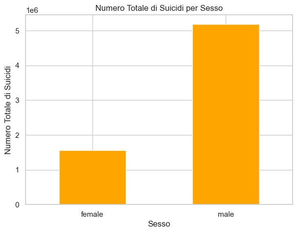

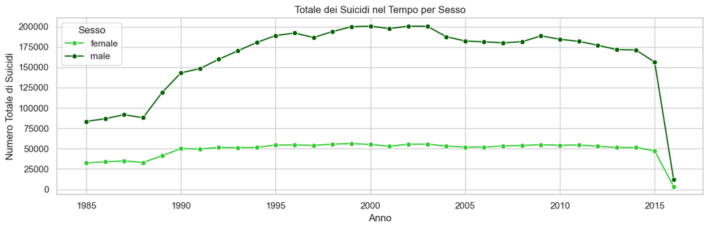

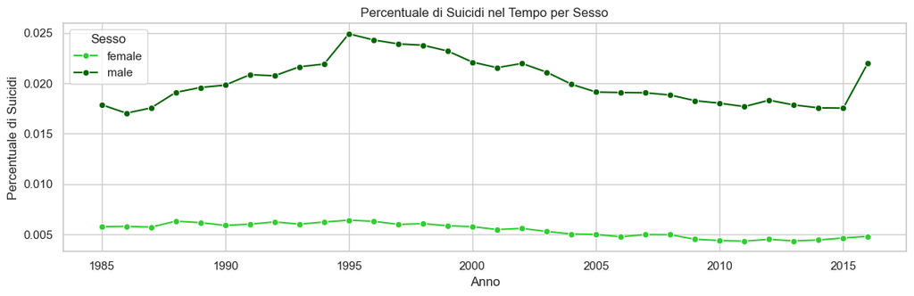

```python
# Calcolo del totale dei suicidi per sesso
suicides_by_sex = df.groupby('sex')['suicides_no'].sum()

# Creazione del grafico a barre
plt.figure(figsize=(7, 5))
suicides_by_sex.plot(kind='bar', color='orange')
plt.title('Numero Totale di Suicidi per Sesso')
plt.xlabel('Sesso')
plt.ylabel('Numero Totale di Suicidi')
plt.xticks(rotation=0)
plt.show()

# Raggruppamento dei dati per sesso e anno, calcolando il totale di suicidi
total_suicides_by_sex_year = df.groupby(['sex', 'year'])['suicides_no'].sum().reset_index()

# Definisci una palette di colori (due tonalità di verde)
green_palette = ["#32CD32", "#006400"]

# Creazione del primo grafico temporale per il totale di suicidi nel tempo per sesso
plt.figure(figsize=(12, 4))
sns.lineplot(x='year', y='suicides_no', hue='sex', data=total_suicides_by_sex_year, marker="o", palette=green_palette)
plt.title('Totale dei Suicidi nel Tempo per Sesso')
plt.xlabel('Anno')
plt.ylabel('Numero Totale di Suicidi')
plt.legend(title='Sesso')

plt.tight_layout()
plt.show()

# Calcolo della percentuale annuale di suicidi per sesso
df['suicides_percentage'] = (df['suicides_no'] / df['population']) * 100

# Raggruppamento dei dati per sesso e anno, calcolando la percentuale media di suicidi
percentage_suicides_by_sex_year = df.groupby(['sex', 'year'])['suicides_percentage'].mean().reset_index()

# Creazione del secondo grafico temporale per le percentuali di suicidi nel tempo per sesso
plt.figure(figsize=(12, 4))
sns.lineplot(x='year', y='suicides_percentage', hue='sex', data=percentage_suicides_by_sex_year, marker="o", palette=green_palette)
plt.title('Percentuale di Suicidi nel Tempo per Sesso')
plt.xlabel('Anno')
plt.ylabel('Percentuale di Suicidi')
plt.legend(title='Sesso')

plt.tight_layout()
plt.show()
```

## 3.3 Analisi globale dei suicidi per fascia d'età

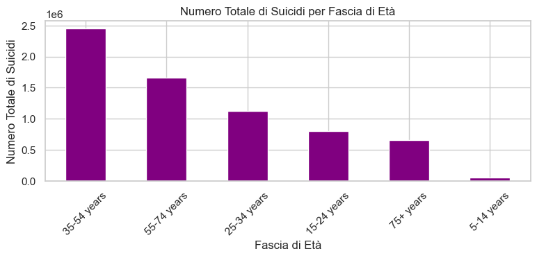

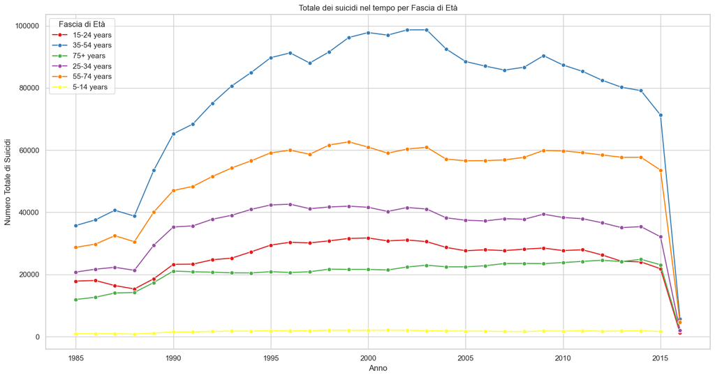

```python
# Calcolo del totale dei suicidi per fascia d'età
suicides_by_age = df.groupby('age')['suicides_no'].sum().sort_values(ascending=False)

# Creazione del grafico a barre
plt.figure(figsize=(9, 3))
suicides_by_age.plot(kind='bar', color='purple')
plt.title('Numero Totale di Suicidi per Fascia di Età')
plt.xlabel('Fascia di Età')
plt.ylabel('Numero Totale di Suicidi')
plt.xticks(rotation=45)
plt.show()

# Creazione di un grafico temporale unico con una linea per ogni fascia d'età
plt.figure(figsize=(15, 8))

age_groups = df['age'].unique()
n_age_groups = len(age_groups)
colors = sns.color_palette("Set1", n_age_groups)

for i, age_group in enumerate(age_groups):
    df_age_group = df[df['age'] == age_group]
    total_suicides_by_age_year = df_age_group.groupby('year')['suicides_no'].sum().reset_index()
    sns.lineplot(x='year', y='suicides_no', data=total_suicides_by_age_year,
                 marker="o", label=age_group, color=colors[i])

plt.title('Totale dei suicidi nel tempo per Fascia di Età')
plt.xlabel('Anno')
plt.ylabel('Numero Totale di Suicidi')
plt.legend(title='Fascia di Età')
plt.tight_layout()
plt.show()
```

## 3.4 Analisi globale dei suicidi, rapporto tra il sesso e fascia d'età

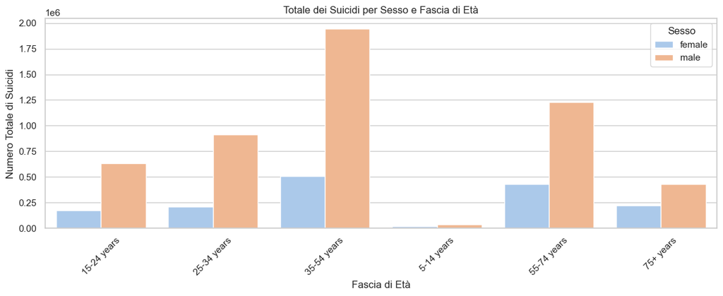

```python
# Raggruppamento dei dati per sesso e fascia d'età e calcolo del totale di suicidi
total_suicides_by_sex_age = df.groupby(['sex', 'age'])['suicides_no'].sum().reset_index()

# Creazione del grafico
plt.figure(figsize=(12, 5))
sns.barplot(x='age', y='suicides_no', hue='sex', data=total_suicides_by_sex_age)
sns.set_palette("pastel")
plt.title('Totale dei Suicidi per Sesso e Fascia di Età')
plt.xlabel('Fascia di Età')
plt.ylabel('Numero Totale di Suicidi')
plt.xticks(rotation=45)
plt.legend(title='Sesso')

plt.tight_layout()
plt.show()
```

## 3.5 Analisi globale sul tasso di suicidi

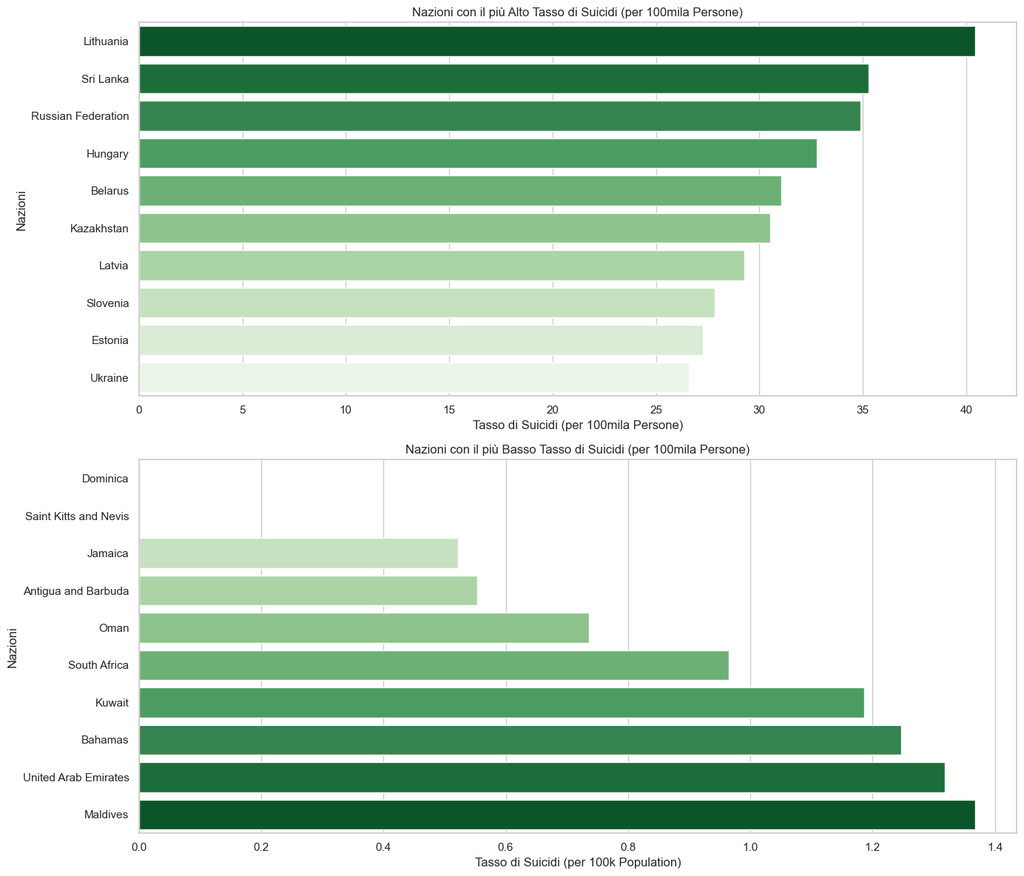

```python
# Calcolare il tasso medio di suicidio per ogni paese
average_suicide_rate = df.groupby('country')['suicides/100k pop'].mean()

# Selezionare i primi 10 paesi con il tasso medio più alto
top_10_countries = average_suicide_rate.nlargest(10)

# Selezionare gli ultimi 10 paesi con il tasso medio più basso
bottom_10_countries = average_suicide_rate.nsmallest(10)

# Creazione dei due grafici a barre orizzontali
plt.figure(figsize=(14, 12))

# Grafico per i primi 10 paesi
plt.subplot(2, 1, 1)
sns.barplot(x=top_10_countries.values, y=top_10_countries.index, hue=top_10_countries.index, palette="Greens_r", dodge=False)
plt.title('Nazioni con il più Alto Tasso di Suicidi (per 100mila Persone)')
plt.xlabel('Tasso di Suicidi (per 100mila Persone)')
plt.ylabel('Nazioni')

# Grafico per gli ultimi 10 paesi
plt.subplot(2, 1, 2)
sns.barplot(x=bottom_10_countries.values, y=bottom_10_countries.index, hue=bottom_10_countries.index, palette="Greens", dodge=False)
plt.title('Nazioni con il più Basso Tasso di Suicidi (per 100mila Persone)')
plt.xlabel('Tasso di Suicidi (per 100k Population)')
plt.ylabel('Nazioni')

plt.tight_layout()
plt.show()
```

## 3.6 Analisi globale sul tasso di suicidi, differenze tra i sessi

[figure not shown]

```python
# Calcoliamo il tasso medio di suicidi per 100k per anno e per sesso
suicides_time_sex = df.groupby(['year', 'sex'])['suicides/100k pop'].mean().reset_index()

# Separazione dei dati per sesso
female_suicides_time = suicides_time_sex[suicides_time_sex['sex'] == 'female']
male_suicides_time = suicides_time_sex[suicides_time_sex['sex'] == 'male']
suicides_sex_rate = df.groupby('sex')['suicides/100k pop'].sum().reset_index()

# Creazione dei grafici
fig, axes = plt.subplots(1, 3, figsize=(24, 8))

# Istogramma a barre verticali per i suicidi per sesso con distinzione di colore
sns.barplot(x='sex', y='suicides/100k pop', hue='sex', data=suicides_sex_rate, ax=axes[0], palette=['purple', 'green'])
axes[0].set_title('Suicidi per 100mila Persone per Sesso')
axes[0].set_ylabel('Suicidi per 100mila Persone')
axes[0].set_xlabel('Sesso')

# Grafico temporale per il tasso di suicidi delle donne con marker
sns.lineplot(x='year', y='suicides/100k pop', data=female_suicides_time, ax=axes[1], color='purple', marker='o')
axes[1].set_title('Trend di Suicidi per 100mila Persone (Femmine)')
axes[1].set_ylabel('Suicidi per 100mila Persone')
axes[1].set_xlabel('Anno')

# Grafico temporale per il tasso di suicidi degli uomini con marker
sns.lineplot(x='year', y='suicides/100k pop', data=male_suicides_time, ax=axes[2], color='green', marker='o')
axes[2].set_title('Trend di Suicidi per 100mila persone (Maschi)')
axes[2].set_ylabel('Suicides per 100mila Persone')
axes[2].set_xlabel('Anno')

# Regolazione dello spazio tra i grafici
plt.tight_layout()

# Mostra i grafici
plt.show()
```

## 3.7 Analisi dei 4 Stati più colpiti

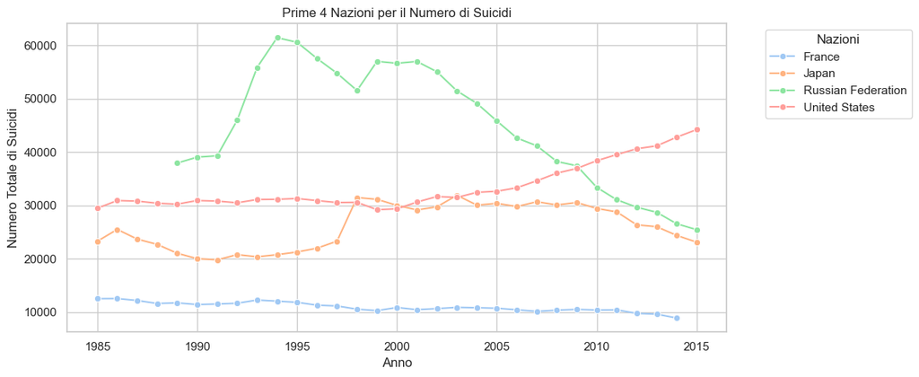

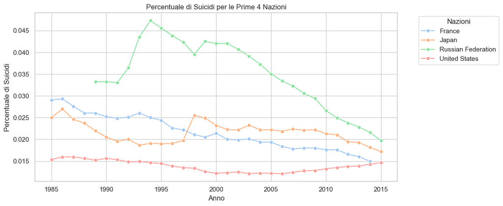

```python
# Identificazione dei primi 4 paesi con il maggior numero di suicidi totali
top_4_countries = df.groupby('country')['suicides_no'].sum().sort_values(ascending=False).head(4).index

# Filtraggio dei dati per includere solo questi 4 paesi
data_top_4_countries = df[df['country'].isin(top_4_countries)]

# Raggruppamento dei dati per paese e anno
total_suicides_by_country_year = data_top_4_countries.groupby(['country', 'year'])['suicides_no'].sum().reset_index()

# Creazione del grafico temporale per i primi 4 paesi
plt.figure(figsize=(12, 5))
sns.lineplot(x='year', y='suicides_no', hue='country', data=total_suicides_by_country_year, marker="o")
plt.title('Prime 4 Nazioni per il Numero di Suicidi')
plt.xlabel('Anno')
plt.ylabel('Numero Totale di Suicidi')
plt.legend(title='Nazioni', bbox_to_anchor=(1.05, 1), loc='upper left')

plt.tight_layout()
plt.show()

# Trova i quattro paesi con il maggior numero totale di suicidi
total_suicides_by_country = df.groupby('country')['suicides_no'].sum().nlargest(4)
top_4_countries = total_suicides_by_country.index.tolist()

# Filtra il DataFrame originale per includere solo i dati dei quattro paesi
df_top_4_countries = df[df['country'].isin(top_4_countries)].copy()

# Calcolo della percentuale annuale di suicidi per paese
df_top_4_countries['suicides_percentage'] = (df_top_4_countries['suicides_no'] / df_top_4_countries['population']) * 100

# Raggruppamento dei dati per paese e anno, calcolando la percentuale media di suicidi
percentage_suicides_by_country_year = df_top_4_countries.groupby(['country', 'year'])['suicides_percentage'].mean().reset_index()

# Creazione del grafico temporale per le percentuali di suicidi
plt.figure(figsize=(12, 5))
sns.lineplot(x='year', y='suicides_percentage', hue='country', data=percentage_suicides_by_country_year, marker="o")
plt.title('Percentuale di Suicidi per le Prime 4 Nazioni')
plt.xlabel('Anno')
plt.ylabel('Percentuale di Suicidi')
plt.legend(title='Nazioni', bbox_to_anchor=(1.05, 1), loc='upper left')

plt.tight_layout()
plt.show()
```

# 4. Analisi dei suicidi in Giappone

# Il dramma dei suicidi: dalla Corea del Sud al Giappone

## Il dramma dei suicidi

Secondo i dati statistici, in un solo mese, i suicidi in Giappone hanno superato i morti totali per colpa della pandemia. Sebbene si possa pensare che la causa scatenante sia stata la situazione tragica dovuta al Covid, essa è solamente un’aggravante. Infatti, la situazione di incertezza globale non ha fatto altro che incentivare le persone verso decisioni tragiche ed irrimediabili. Ma per quale motivo si arriva al suicidio? E inoltre, perché proprio la Corea del Sud ed il Giappone sono interessanti da tutti questi casi?

## Le condizioni di stress ed insoddisfazione tra le cause

Chi pensa al suicido lo fa perché, sostanzialmente, si trova in una situazione in cui non vede una via d’uscita. Gli stati d’animo che accompagnano una decisione del genere sono estremamente personali e si legano a questioni drammatiche e molto serie.

Andando ad analizzare il contesto sociale del fenomeno, possiamo però andare ad elencare alcune delle ragioni più rappresentative e ricorrenti. Infatti, molto spesso le cause scatenanti si legano a problematiche quali la vita lavorativa, la situazione nel contesto famigliare e le pressioni sociali.

La pressione sociale in particolare è molto diffusa in tutto il mondo globalizzato e basato sul capitalismo. La logica del guadagno spinge le persone ad orari lavorativi sovrannaturali, che non lasciano possibilità di tempo libero e personale. C’è chi può sentirsi sopraffatto, arrivando ad avere problemi per quanto riguarda la salute mentale.

Queste problematiche, se non trattate adeguatamente, possono peggiorare e portare all’isolamento delle persone, che non esprimono apertamente i propri pensieri e non trovano momenti di sfogo.

Perché in Corea del Sud e in Giappone ci sono più suicidi? In oriente la pressione sociale è molto alta, a tratti logorante. In Giappone e in Corea del Sud, il suicidio è diventato la prima causa di morte per chi ancora non ha raggiunto i 40 anni. Segnale chiaro del fatto che questa tipologia di fenomeni, come le manifestazioni di depressione, non sono da sottovalutare.

Dall’esterno vediamo i risultati di una politica economica efficace, che ha portato i giapponesi e i coreani a vivere una situazione sociale positiva. Ci sono industrie sviluppate ed un efficace sistema economico, che fa concorrenza all’occidente.

Ma la vita sociale non rispecchia la vita lavorativa delle persone. Ci troviamo di fronte ad una pressione che spinge la popolazione verso la completa eccellenza. Ed è proprio questa la parola chiave: eccellere è l’unica possibilità. Chi non ci riesce è considerato come non degno di attenzione. Bisogna avere talento, stare al passo con i tempi che cambiano e guadagnare, entrando ogni giorno in una competizione spietata con gli altri.

## La foresta dei suicidi in Giappone

Se il Giappone si trova ai primi posti tra i paesi con maggiori suicidi, c’è anche un altro inquietante record da aggiungere. Infatti, in questo paese è presente la foresta dove si sono verificati più suicidi al mondo: si trova sotto al monte Fuji ed è la foresta Jukai. È stato calcolato che, in essa, c’è una media di 30 suicidi all’anno. Il maggior numero di suicidi viene calcolato nel mese di marzo, momento dell’anno in cui i giapponesi sono tenuti a realizzare i propri rendiconti finanziari riguardanti i 12 mesi precedenti. Ciò ci porta a comprendere come la struttura economica e sociale sia colpevole della gran parte di queste decisioni drammatiche.

Non sono chiare le motivazioni che portano così tante persone a decidere di suicidarsi proprio in questa foresta. Sicuramente la fitta vegetazione, il silenzio e la tranquillità del luogo giocano il proprio ruolo, come anche la notorietà del luogo, che lo rende in un certo senso simbolico.

## 4.1 Analisi dei suicidi in Giappone

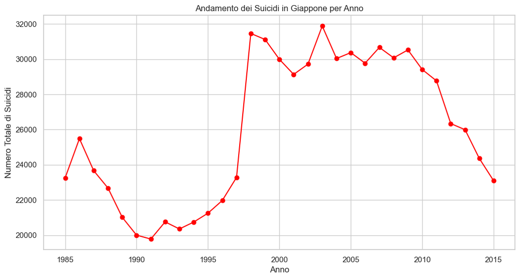

```python
# Filtriamo i dati per il Giappone
df_japan = df[df['country'] == 'Japan']

# Calcolo del totale dei suicidi per anno in Giappone
suicides_japan_per_year = df_japan.groupby('year')['suicides_no'].sum()

# Creazione del grafico
plt.figure(figsize=(12, 6))
suicides_japan_per_year.plot(kind='line', color='red', marker='o')
plt.title('Andamento dei Suicidi in Giappone per Anno')
plt.xlabel('Anno')
plt.ylabel('Numero Totale di Suicidi')
plt.grid(True)
plt.show()
```

## 4.2 Analisi sul tasso di suicidi in Giappone

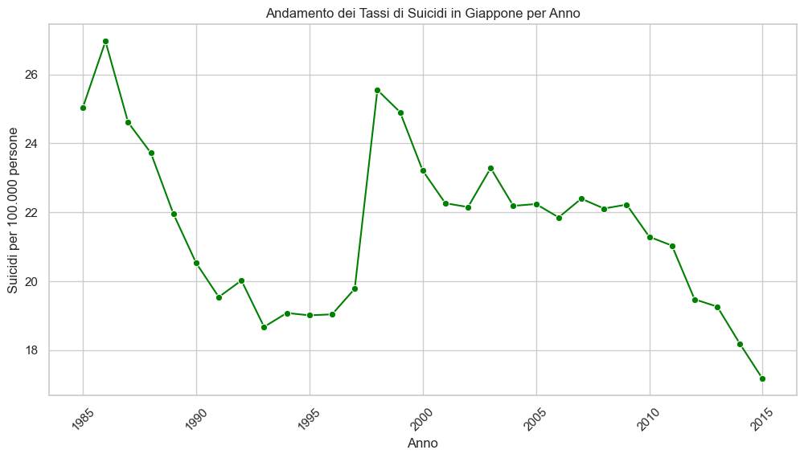

```python
# Filtra i dati per il Giappone
df_japan = df[df['country'] == 'Japan']

#Andamento dei tassi di suicidio in Giappone
suicide_rate_japan_year = df_japan.groupby('year')['suicides/100k pop'].mean()

plt.figure(figsize=(12, 6))
sns.lineplot(x=suicide_rate_japan_year.index, y=suicide_rate_japan_year.values, marker='o', color='Green')
plt.title('Andamento dei Tassi di Suicidi in Giappone per Anno')
plt.xlabel('Anno')
plt.ylabel('Suicidi per 100mila persone')
plt.xticks(rotation=45)
plt.grid(True)
plt.show()
```

## 4.3 Analisi dei suicidi in Giappone, differenze tra i sessi

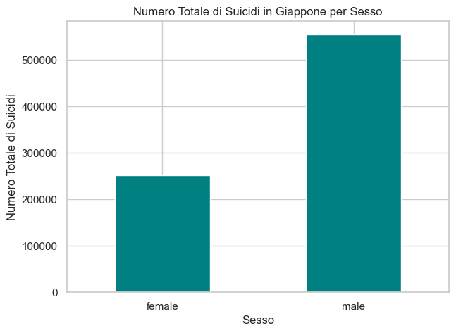

```python
# Calcolo del totale dei suicidi per sesso in Giappone
suicides_japan_by_sex = df_japan.groupby('sex')['suicides_no'].sum()

# Creazione del grafico a barre
plt.figure(figsize=(7, 5))
suicides_japan_by_sex.plot(kind='bar', color='teal')
plt.title('Numero Totale di Suicidi in Giappone per Sesso')
plt.xlabel('Sesso')
plt.ylabel('Numero Totale di Suicidi')
plt.xticks(rotation=0)
plt.show()
```

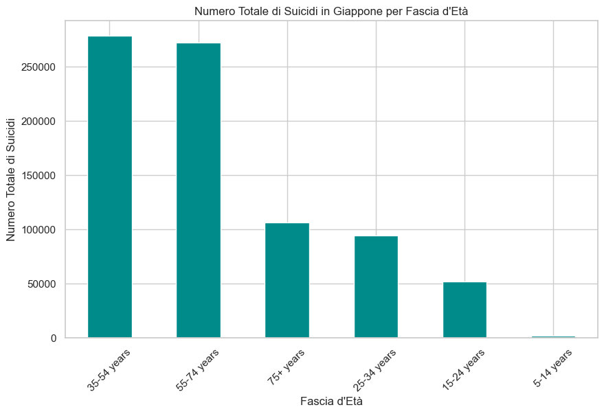

```python
# Calcolo del totale dei suicidi per fascia d'età in Giappone
suicides_japan_by_age = df_japan.groupby('age')['suicides_no'].sum().sort_values(ascending=False)

# Creazione del grafico a barre
plt.figure(figsize=(10, 6))
suicides_japan_by_age.plot(kind='bar', color='darkcyan')
plt.title('Numero Totale di Suicidi in Giappone per Fascia di Età')
plt.xlabel('Fascia di Età')
plt.ylabel('Numero Totale di Suicidi')
plt.xticks(rotation=45)
plt.show()
```

[figure not shown]

```python
# Filtrare i dati per il Giappone
df_japan = df[df['country'] == 'Japan']

# Raggruppamento dei dati per il Giappone per fascia d'età e sesso, calcolando la somma dei suicidi
grouped_data_japan = df_japan.groupby(['age', 'sex'])['suicides_no'].sum().reset_index()

# Creazione dell'istogramma a barre per il Giappone
plt.figure(figsize=(10, 5))
sns.barplot(x='age', y='suicides_no', hue='sex', data=grouped_data_japan, palette=['#e74c3c', '#3498db'])

# Impostazioni del grafico
plt.title('Numero di Suicidi in Giappone per Fasce di Età e Sesso')
plt.xlabel('Fascia di Età')
plt.ylabel('Numero di Suicidi')
plt.xticks(rotation=45)
plt.legend(title='Sesso')

# Mostra il grafico
plt.show()
```

# 5. Risultati e Conclusioni

## Risultati chiave

Nel corso di questo studio, sono andato ad analizzare il trend dei suicidi nel mondo con un focus particolare sul Giappone. I risultati hanno mostrato diverse tendenze significative:

### - Andamento temporale

Abbiamo osservato variazioni nel tasso di suicidi in Giappone nel corso degli anni, con un andamento che necessita di ulteriori indagini per comprendere meglio le cause di queste fluttuazioni.

### - Differenze di genere

I dati hanno evidenziato una differenza significativa nei tassi di suicidio tra uomini e donne, suggerendo la necessità di politiche di prevenzione e supporto mirate.

### - Impatto per fascia d'età

L'analisi per fascia d'età ha rivelato che certi gruppi sono più vulnerabili rispetto ad altri, sottolineando l'importanza di strategie di intervento specifiche.

## Implicazioni e riflessioni

Questi risultati evidenziano l'importanza di considerare fattori come genere e età nell'elaborazione di strategie per la prevenzione del suicidio. È chiaro che le politiche pubbliche e le iniziative di sensibilizzazione devono essere personalizzate per affrontare efficacemente le esigenze di gruppi diversi.

Inoltre, la variazione dei tassi di suicidio nel tempo suggerisce che fattori socio-economici, culturali e ambientali giocano un ruolo cruciale. Pertanto, la prevenzione del suicidio richiede un approccio olistico che consideri tutti questi elementi.

## Limitazioni e direzioni future

Il presente studio presenta alcune limitazioni, in particolare riguardo alla disponibilità e alla qualità dei dati raccolti. È importante notare che alcune nazioni non sono incluse nell'analisi e che l'assenza di date precise relative ai suicidi non permette di determinare con esattezza il periodo in cui si sono verificati. Questo aspetto potrebbe influenzare significativamente i risultati, in quanto in alcune nazioni diversi periodi potrebbero essere caratterizzati da un aumento dei tassi di suicidio, rendendo così la generalizzabilità dei risultati meno affidabile. Inoltre, i dati utilizzati non consentono di indagare le cause specifiche dei suicidi, richiedendo quindi cautela nell'interpretazione dei risultati.

## Approfondimenti

https://www.bbc.com/news/world-33362387

https://edition.cnn.com/2020/11/28/asia/japan-suicide-women-covid-dst-intl-hnk/index.html

https://www.repubblica.it/esteri/2020/11/29/news/coronavirus_allarme_suicidi_giappone-276311533/

https://it.m.wikipedia.org/wiki/Aokigahara

## Conclusioni

Questo studio fornisce un quadro complessivo del fenomeno suicidario a livello globale, con una particolare attenzione al caso del Giappone. I risultati sottolineano l'importanza di approcci mirati e differenziati nella prevenzione del suicidio, considerando le diverse esigenze di genere, età e contesto socio-culturale.